# Hands-on Session I: Proteomic and Metabolomic Characterization of COVID-19 Patient Sera

Cristina Torredemer Ortega (cristina.torredemer01@estudiant.upf.edu)

Last update: 26 March, 2026

# Introduction

This practical focuses on data wrangling, exploratory data analysis, visualization, and critical comparison with published results using real biomedical data.

We will work with the publication [**Proteomic and Metabolomic Characterization of COVID-19 Patient Sera**](https://www.sciencedirect.com/science/article/pii/S0092867420306279)

# Exercise 1: Data Loading and Cleaning

**Download and load Supplementary Table 1 (“Additional Demographical and Baseline Characteristics of COVID-19 Patients and Control Groups”) from the supplementary materials of the publication.**

The study analyzed proteomic and metabolomic profiles of sera from 46 COVID-19 patients and 53 control individuals. Using machine learning, the authors identified 22 proteins and 7 metabolites that could classify severe versus non-severe patients. The data used here comes from Supplementary Table S1, which contains demographic and clinical laboratory information for 118 individuals across four groups: healthy controls, non-COVID-19 patients, non-severe COVID-19, and severe COVID-19. The dataset includes 31 variables covering patient identifiers, dates, demographic characteristics, and 12 clinical laboratory measurements.

```r
library(tidyverse)
library(readxl)
library(janitor)
library(naniar)
library(rstatix)
library(ggpubr)
library(pheatmap)
library(table1)
library(htmltools)
library(xml2)
library(rvest)
```

```r
data <- read_excel("data/raw_data/Table_S1.xlsx", sheet = "Clinical_information")

dim(data)
```

```
## [1] 118  31
```

```r
str(data)
```

The dataset contains 118 samples and 31 variables.

```r
# Date cleaning & format harmonization

# Fix dates stored as Excel serial numbers
data$`Date of progression to severe state` <- as.Date(
  as.numeric(data$`Date of progression to severe state`),
  origin = "1899-12-30"
)

data$`Sampling date for proteomics` <- as.Date(
  as.numeric(data$`Sampling date for proteomics`),
  origin = "1899-12-30"
)

# Replace "/" entries with NA in character columns
cols_with_slash <- names(which(
  sapply(data, function(col) is.character(col) && any(col == "/", na.rm = TRUE))
))

data[cols_with_slash] <- lapply(data[cols_with_slash], function(col) {
  col[col == "/"] <- NA
  col
})

# Convert POSIXct columns to Date
posix_cols <- sapply(data, inherits, what = "POSIXt")
data[posix_cols] <- lapply(data[posix_cols], as.Date)
```

```r
# Save the full dataset
data_full <- data

# Remove technical ID variables not useful for EDA
data_eda <- data_full %>%
  select(-`MS ID b`, -`MSRep ID c`, -`Metabolomics ID e`)

# IMPORTANT: Clean column names FIRST, THEN encode factors
# (doing it the other way round causes factor levels to become NA)
data_eda <- data_eda %>%
  clean_names(replace = c("μ" = "u"))

# Now encode factors using the CLEANED column names
data_eda$group_d <- factor(
  data_eda$group_d,
  levels = c(0, 1, 2, 3),
  labels = c("healthy", "non-COVID-19", "non-Severe", "Severe")
)

data_eda$sex_g <- factor(
  data_eda$sex_g,
  levels = c(0, 1),
  labels = c("Female", "Male")
)

# Ensure numeric types for BMI and CRP (may have been read as character)
data_eda$bmi_h <- as.numeric(data_eda$bmi_h)
data_eda$crp_i_mg_l <- as.numeric(data_eda$crp_i_mg_l)

# Drop unused factor levels
data_eda$group_d <- droplevels(data_eda$group_d)

# Verify the factor encoding worked
table(data_eda$group_d, useNA = "always")
table(data_eda$sex_g, useNA = "always")

# Define the 12 clinical variables for downstream analyses
clinical_variables <- c(
  "bmi_h",
  "wbc_count_109_l",
  "lymphocyte_count_109_l",
  "monocyte_count_109_l",
  "platelet_count_109_l",
  "crp_i_mg_l",
  "alt_j_u_l",
  "ast_k_u_l",
  "ggt_l_u_l",
  "tbil_m_umol_l",
  "dbil_n_umol_l",
  "creatinine_umol_l",
  "glucose_mmol_l"
)

# Readable labels for clinical variables (used in plots)
clinical_labels <- c(
  "wbc_count_109_l"        = "White blood cell (WBC)",
  "lymphocyte_count_109_l" = "Lymphocyte",
  "monocyte_count_109_l"   = "Monocyte",
  "platelet_count_109_l"   = "Platelet",
  "crp_i_mg_l"             = "C-reactive protein (CRP)",
  "alt_j_u_l"              = "Alanine aminotransferase (ALT)",
  "ast_k_u_l"              = "Aspartate aminotransferase (AST)",
  "ggt_l_u_l"              = "Glutamyltransferase (GGT)",
  "tbil_m_umol_l"          = "Total bilirubin (TBIL)",
  "dbil_n_umol_l"          = "Direct bilirubin (DBIL)",
  "creatinine_umol_l"      = "Creatinine",
  "glucose_mmol_l"         = "Glucose"
)

colnames(data_eda)
```

## Exercise 1.1

Reproduce Table 1 from the manuscript using the supplementary data. Match the reported summary statistics as closely as possible.

Briefly discuss any discrepancies between your results and the published table, and provide possible explanations.

```r
# Custom render functions to match the paper's Table 1 format

my.render.cont <- function(x) {
  with(stats.apply.rounding(stats.default(x)), {
    out <- c("",
             "Mean ± SD"    = sprintf("%s ± %s", MEAN, SD),
             "Median (IQR)" = sprintf("%s (%s–%s)", MEDIAN, Q1, Q3),
             "Range"        = sprintf("%s–%s", MIN, MAX))
    out[names(out) != "Missing"]
  })
}

my.render.cat <- function(x) {
  c("", sapply(levels(x), function(lv) {
    n <- sum(x == lv, na.rm = TRUE)
    N <- sum(!is.na(x))
    sprintf("%d (%.1f)", n, 100 * n / N)
  }, USE.NAMES = TRUE))
}
```

```r
# Create a duplicate set of COVID-19 rows to form the "Total COVID" column

data_tab1 <- bind_rows(
  data_eda %>%
    mutate(group_tab1 = as.character(group_d)),

  data_eda %>%
    filter(group_d %in% c("non-Severe", "Severe")) %>%
    mutate(group_tab1 = "Total COVID")
)

data_tab1$group_tab1 <- factor(
  data_tab1$group_tab1,
  levels = c("healthy", "non-COVID-19", "Total COVID", "non-Severe", "Severe")
)

# Compute time-to-event variables
# The paper reports integer day counts; we compute them from dates.
# A +1 adjustment is applied to match the convention where same-day = 1 day.

data_tab1 <- data_tab1 %>%
  mutate(
    time_from_onset_to_admission_days =
      ifelse(
        !is.na(onset_date_f) & !is.na(admission_date),
        as.numeric(admission_date - onset_date_f) + 1,
        NA_real_
      ),

    time_from_admission_to_severe_days =
      ifelse(
        group_d == "Severe" &
          !is.na(admission_date) &
          !is.na(date_of_progression_to_severe_state),
        as.numeric(date_of_progression_to_severe_state - admission_date) + 1,
        NA_real_
      )
  )
```

```r
# Build Table 1 with available variables

table_1_data <- data_tab1 %>%
  select(
    group_tab1,
    sex_g,
    age_year,
    bmi_h,
    time_from_onset_to_admission_days,
    time_from_admission_to_severe_days
  )

# Label variables for display
label(table_1_data$sex_g) <- "Sex - no. (%)"
label(table_1_data$age_year) <- "Age - year"
label(table_1_data$bmi_h) <- "BMI, kg/m²"
label(table_1_data$time_from_onset_to_admission_days) <- "Time from Onset to Admission, Days"
label(table_1_data$time_from_admission_to_severe_days) <- "Time from Admission to Severe, Days"

table1(
  ~ sex_g +
    age_year +
    bmi_h +
    time_from_onset_to_admission_days +
    time_from_admission_to_severe_days |
    group_tab1,
  data = table_1_data,
  render.continuous = my.render.cont,
  render.categorical = my.render.cat,
  overall = FALSE,
  topclass = "Rtable1-zebra",
  caption = "Table 1. Demographic and Baseline Characteristics by Disease Group"
)
```

Table 1. Demographic and Baseline Characteristics by Disease Group

|  | healthy (N=28) | non-COVID-19 (N=25) | Total COVID (N=65) | non-Severe (N=37) | Severe (N=28) |
| --- | --- | --- | --- | --- | --- |
| Sex - no. (%) |  |  |  |  |  |
| Female | 7 (25.0) | 8 (32.0) | 26 (40.0) | 14 (37.8) | 12 (42.9) |
| Male | 21 (75.0) | 17 (68.0) | 39 (60.0) | 23 (62.2) | 16 (57.1) |
| Age - year |  |  |  |  |  |
| Mean ± SD | 44.4 ± 8.26 | 49.2 ± 14.0 | 48.1 ± 13.9 | 42.9 ± 12.5 | 54.8 ± 12.8 |
| Median (IQR) | 45.0 (38.0–51.0) | 53.0 (38.0–61.0) | 47.0 (37.0–56.0) | 43.0 (36.0–51.0) | 55.0 (47.0–64.3) |
| Range | 28.0–57.0 | 23.0–67.0 | 18.0–77.0 | 18.0–70.0 | 30.0–77.0 |
| BMI, kg/m² |  |  |  |  |  |
| Mean ± SD | 24.4 ± 2.71 | 23.5 ± 2.68 | 24.9 ± 2.98 | 24.5 ± 3.21 | 25.5 ± 2.52 |
| Median (IQR) | 24.2 (22.5–26.1) | 24.7 (21.1–25.4) | 24.7 (22.6–26.9) | 24.2 (21.9–26.7) | 24.9 (24.1–27.1) |
| Range | 19.9–32.9 | 19.1–27.4 | 18.9–31.3 | 18.9–30.7 | 21.1–31.3 |
| Missing | 0 (0%) | 5 (20.0%) | 3 (4.6%) | 0 (0%) | 3 (10.7%) |
| Time from Onset to Admission, Days |  |  |  |  |  |
| Mean ± SD | NA ± NA | NA ± NA | 6.00 ± 4.42 | 4.59 ± 3.17 | 7.86 ± 5.17 |
| Median (IQR) | NA (NA–NA) | NA (NA–NA) | 4.00 (3.00–9.00) | 4.00 (3.00–5.00) | 8.50 (3.00–11.0) |
| Range | NA–NA | NA–NA | 1.00–24.0 | 1.00–15.0 | 1.00–24.0 |
| Missing | 28 (100%) | 25 (100%) | 0 (0%) | 0 (0%) | 0 (0%) |
| Time from Admission to Severe, Days |  |  |  |  |  |
| Mean ± SD | NA ± NA | NA ± NA | 2.39 ± 1.66 | NA ± NA | 2.39 ± 1.66 |
| Median (IQR) | NA (NA–NA) | NA (NA–NA) | 2.00 (1.00–3.25) | NA (NA–NA) | 2.00 (1.00–3.25) |
| Range | NA–NA | NA–NA | 0–7.00 | NA–NA | 0–7.00 |
| Missing | 28 (100%) | 25 (100%) | 37 (56.9%) | 37 (100%) | 0 (0%) |

### Discrepancies with the published Table 1

The supplementary data (Table S1) only provides demographic variables (sex, age, BMI) and clinical laboratory measurements. It does not include smoking status, alcohol use, symptoms (fever, cough, headache, fatigue, pharyngalgia, expectoration, diarrhea, chest tightness), chest CT findings, comorbidities (hypertension, diabetes, respiratory, endocrine, kidney, digestive), oxygenation index, or treatment variables (oxygen inhalation, antibiotics, antiviral drugs, immunoglobulin, methylprednisolone, Chinese medicine). Therefore, those rows of the published Table 1 cannot be reproduced from the available supplementary data alone.

For the variables that can be compared, the reproduced statistics closely match the published values. Minor numerical discrepancies may arise from differences in rounding conventions and the handling of time-to-event calculations. The paper reports “Time from Onset to Admission” with a mean of 6.1 ± 4.4 days for total COVID-19 patients; depending on whether the calculation includes or excludes the onset/admission day itself (±1 day), slight differences can appear. Overall, the reproducible statistics (sex distribution, age, BMI) are consistent with the published table.

## Exercise 1.2

Perform an exploratory data analysis (EDA) of the dataset. At a minimum, include:

- Descriptive statistics for key variables
- Appropriate visualizations (e.g. distributions, group comparisons)
- A brief written summary of notable patterns, anomalies, or data quality issues

### Missing data analysis

Missing data analysis is performed to quantify overall missingness, assess whether missingness differs by patient group, and determine whether missing values are structurally driven (due to clinical relevance) rather than data quality issues.

```r
# Missing values per variable
missing_summary <- data_eda %>%
  summarise(across(everything(), ~ sum(is.na(.)))) %>%
  pivot_longer(everything(), names_to = "variable", values_to = "missing_n") %>%
  mutate(missing_pct = round(missing_n / nrow(data_eda) * 100, 1))

missing_summary %>% filter(missing_n > 0)
```

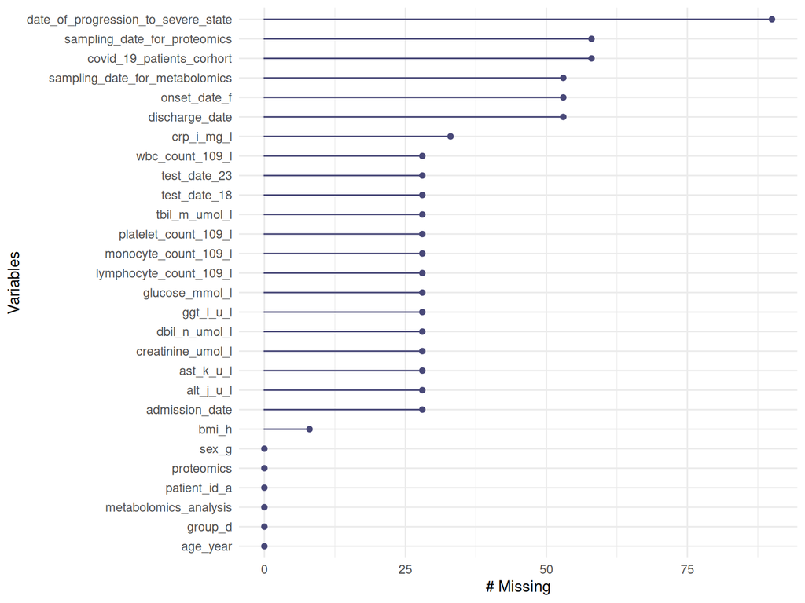

```r
# Lollipop plot of missing data
gg_miss_var(data_eda)
```

Date of progression to severe state has the highest missingness (>75%), followed by sampling dates, cohort assignment, onset date and discharge date. These are all variables that apply only to specific patient subgroups.

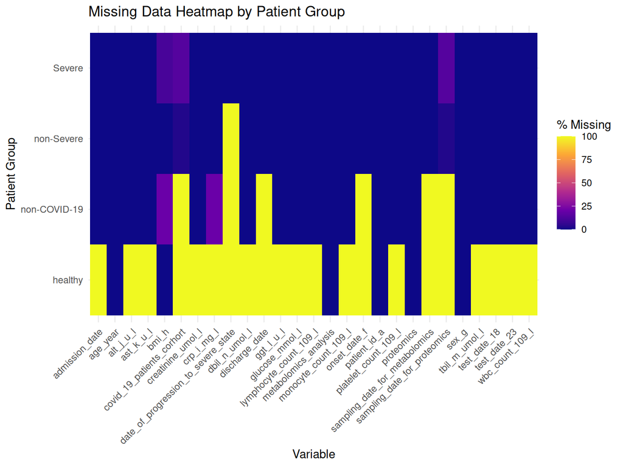

```r
# Missing data by patient group

missing_by_group <- data_eda %>%
  group_by(group_d) %>%
  summarise(
    across(everything(), ~ round(mean(is.na(.)) * 100, 1), .names = "{.col}")
  )

missing_long <- missing_by_group %>%
  pivot_longer(cols = -group_d, names_to = "variable", values_to = "missing_pct")

ggplot(missing_long, aes(x = variable, y = group_d, fill = missing_pct)) +
  geom_tile() +
  scale_fill_viridis_c(option = "C") +
  labs(
    title = "Missing Data Heatmap by Patient Group",
    x = "Variable", y = "Patient Group", fill = "% Missing"
  ) +
  theme_minimal() +
  theme(axis.text.x = element_text(angle = 45, hjust = 1))
```

The heatmap confirms that variables with substantial missingness are primarily associated with clinical events not applicable to healthy or non-COVID-19 patients. The healthy group has 100% missing data in almost every clinical variable except sex and age. This pattern shows that missing values are structurally induced rather than arising from data collection errors.

### Descriptive statistics

```r
# Group-wise descriptive statistics using median and IQR (robust to skewness)

group_clinical_summary <- data_eda %>%
  group_by(group_d) %>%
  summarise(
    across(
      all_of(clinical_variables),
      list(
        median = ~ median(.x, na.rm = TRUE),
        q1     = ~ quantile(.x, 0.25, na.rm = TRUE),
        q3     = ~ quantile(.x, 0.75, na.rm = TRUE)
      ),
      .names = "{.col}_{.fn}"
    ),
    .groups = "drop"
  )

group_clinical_summary
```

```
## # A tibble: 4 × 40
##   group_d      bmi_h_median bmi_h_q1 bmi_h_q3 wbc_count_109_l_median
##   <fct>               <dbl>    <dbl>    <dbl>                  <dbl>
## 1 healthy              24.2     22.5     26.1                  NA
## 2 non-COVID-19         24.7     21.1     25.4                   7.5
## 3 non-Severe           24.2     21.9     26.7                   5.24
## 4 Severe               24.9     24.1     27.1                   6.10
## # ℹ 35 more variables: wbc_count_109_l_q1 <dbl>, wbc_count_109_l_q3 <dbl>,
## #   lymphocyte_count_109_l_median <dbl>, lymphocyte_count_109_l_q1 <dbl>,
## #   lymphocyte_count_109_l_q3 <dbl>, monocyte_count_109_l_median <dbl>,
## #   monocyte_count_109_l_q1 <dbl>, monocyte_count_109_l_q3 <dbl>,
## #   platelet_count_109_l_median <dbl>, platelet_count_109_l_q1 <dbl>,
## #   platelet_count_109_l_q3 <dbl>, crp_i_mg_l_median <dbl>,
## #   crp_i_mg_l_q1 <dbl>, crp_i_mg_l_q3 <dbl>, alt_j_u_l_median <dbl>, …
```

### Normality assessment

Distributional properties of clinical variables are assessed using histograms, Q-Q plots, and Shapiro-Wilk tests to determine whether parametric or non-parametric methods are appropriate.

```r
# Reshape clinical variables to long format for unified plotting

long_clinical <- data_eda %>%
  pivot_longer(
    cols = all_of(clinical_variables),
    names_to = "variable",
    values_to = "value"
  ) %>%
  filter(!is.na(value))
```

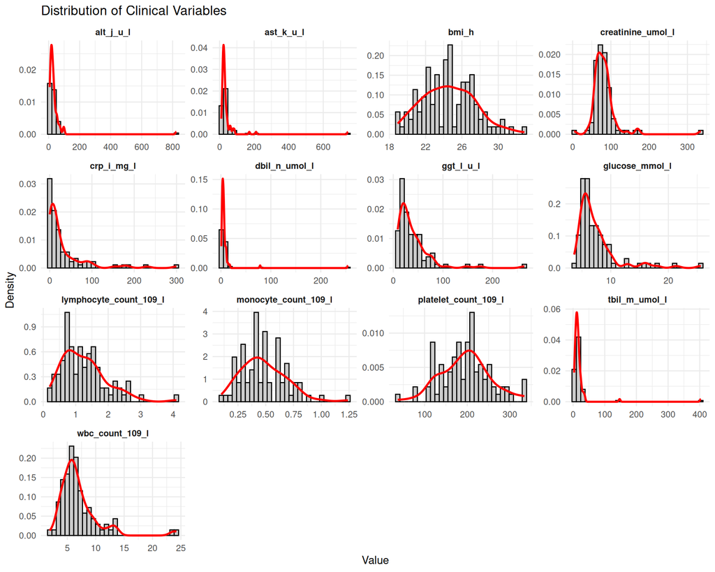

```r
ggplot(long_clinical, aes(x = value)) +
  geom_histogram(aes(y = after_stat(density)),
                 bins = 30, fill = "grey80", color = "black") +
  geom_density(color = "red", linewidth = 1) +
  facet_wrap(~ variable, scales = "free") +
  labs(title = "Distribution of Clinical Variables", x = "Value", y = "Density") +
  theme_minimal() +
  theme(strip.text = element_text(face = "bold"))
```

Most variables show right-skewed distributions (ALT, AST, CRP, GGT, bilirubin, glucose), while BMI and platelet count appear approximately symmetric.

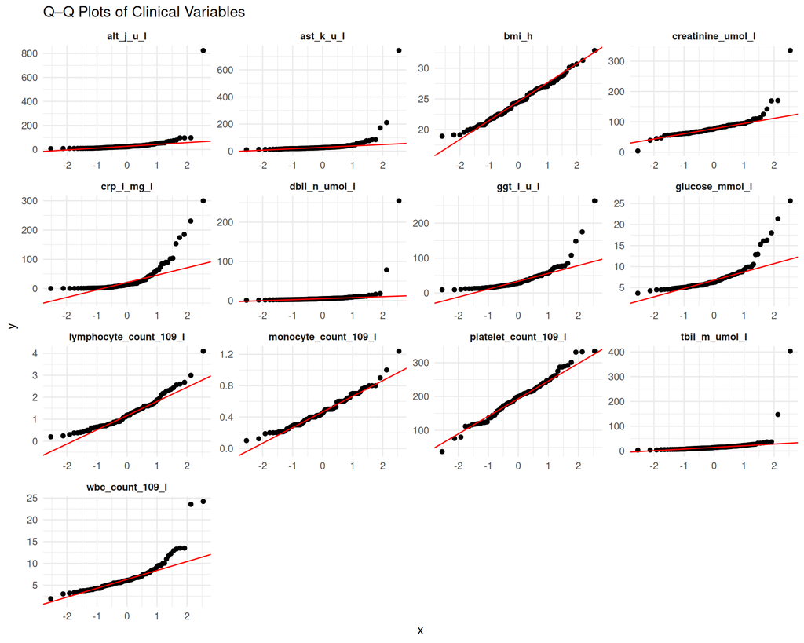

```r
ggplot(long_clinical, aes(sample = value)) +
  stat_qq() +
  stat_qq_line(color = "red") +
  facet_wrap(~ variable, scales = "free") +
  labs(title = "Q–Q Plots of Clinical Variables") +
  theme_minimal() +
  theme(strip.text = element_text(face = "bold"))
```

```r
normality_tests <- long_clinical %>%
  group_by(variable) %>%
  summarise(
    n = n(),
    shapiro_p = ifelse(n <= 5000, shapiro.test(value)$p.value, NA_real_)
  )

normality_tests
```

```
## # A tibble: 13 × 3
##    variable                   n shapiro_p
##    <chr>                  <int>     <dbl>
##  1 alt_j_u_l                 90  1.65e-19
##  2 ast_k_u_l                 90  3.68e-19
##  3 bmi_h                    110  3.53e- 1
##  4 creatinine_umol_l         90  1.79e-13
##  5 crp_i_mg_l                85  2.09e-13
##  6 dbil_n_umol_l             90  5.75e-20
##  7 ggt_l_u_l                 90  3.61e-13
##  8 glucose_mmol_l            90  3.59e-12
##  9 lymphocyte_count_109_l    90  6.89e- 5
## 10 monocyte_count_109_l      90  1.01e- 2
## 11 platelet_count_109_l      90  6.33e- 1
## 12 tbil_m_umol_l             90  1.85e-19
## 13 wbc_count_109_l           90  7.48e-11
```

The Shapiro-Wilk test confirms that most clinical variables deviate significantly from normality (p < 0.05), with the exception of BMI and platelet count. Given these results, non-parametric methods will be used for group comparisons.

### Group comparisons

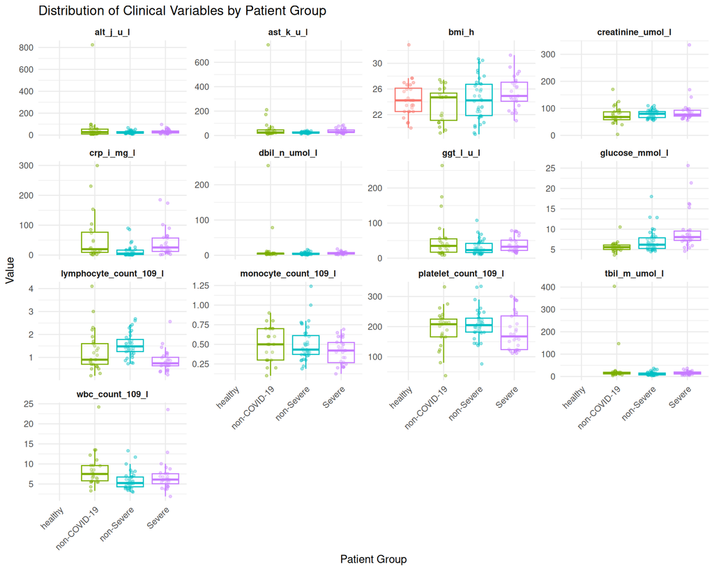

```r
ggplot(long_clinical, aes(x = group_d, y = value, color = group_d)) +
  geom_jitter(width = 0.15, alpha = 0.4, size = 1) +
  geom_boxplot(alpha = 0.3, outlier.shape = NA) +
  facet_wrap(~ variable, scales = "free_y") +
  labs(
    title = "Distribution of Clinical Variables by Patient Group",
    x = "Patient Group", y = "Value"
  ) +
  theme_minimal() +
  theme(
    legend.position = "none",
    axis.text.x = element_text(angle = 45, hjust = 1),
    strip.text = element_text(face = "bold")
  )
```

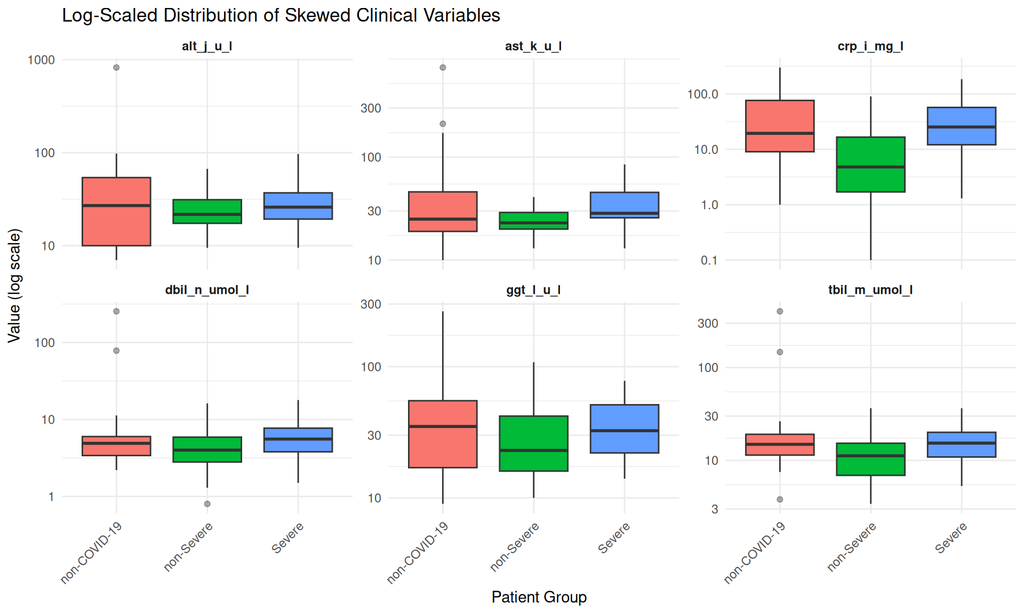

```r
# Log-scaled boxplots for the most skewed variables

skewed_vars <- c("crp_i_mg_l", "alt_j_u_l", "ast_k_u_l",
                 "ggt_l_u_l", "tbil_m_umol_l", "dbil_n_umol_l")

ggplot(
  filter(long_clinical, variable %in% skewed_vars),
  aes(x = group_d, y = value, fill = group_d)
) +
  geom_boxplot(outlier.alpha = 0.4) +
  scale_y_log10() +
  facet_wrap(~ variable, scales = "free_y") +
  labs(
    title = "Log-Scaled Distribution of Skewed Clinical Variables",
    x = "Patient Group", y = "Value (log scale)"
  ) +
  theme_minimal() +
  theme(
    legend.position = "none",
    axis.text.x = element_text(angle = 45, hjust = 1),
    strip.text = element_text(face = "bold")
  )
```

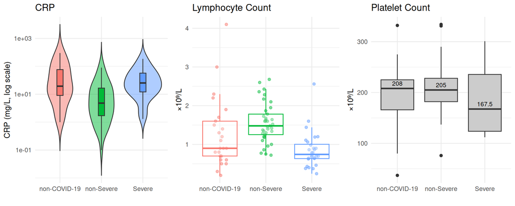

```r
# Individual key variable plots

p1 <- ggplot(
  filter(long_clinical, variable == "crp_i_mg_l"),
  aes(x = group_d, y = value, fill = group_d)
) +
  geom_violin(trim = FALSE, alpha = 0.5) +
  geom_boxplot(width = 0.15, outlier.shape = NA) +
  scale_y_log10() +
  labs(title = "CRP", x = "", y = "CRP (mg/L, log scale)") +
  theme_minimal() + theme(legend.position = "none")

p2 <- ggplot(
  filter(long_clinical, variable == "lymphocyte_count_109_l"),
  aes(x = group_d, y = value, color = group_d)
) +
  geom_jitter(width = 0.15, alpha = 0.5) +
  geom_boxplot(alpha = 0.3, outlier.shape = NA) +
  labs(title = "Lymphocyte Count", x = "", y = "×10⁹/L") +
  theme_minimal() + theme(legend.position = "none")

p3 <- ggplot(
  filter(long_clinical, variable == "platelet_count_109_l"),
  aes(x = group_d, y = value)
) +
  geom_boxplot(fill = "grey80") +
  stat_summary(fun = median, geom = "text",
               aes(label = round(after_stat(y), 1)),
               vjust = -0.6, size = 3) +
  labs(title = "Platelet Count", x = "", y = "×10⁹/L") +
  theme_minimal()

ggarrange(p1, p2, p3, ncol = 3)
```

### Statistical tests

```r
# Kruskal-Wallis test: is at least one group different?

kruskal_results <- long_clinical %>%
  group_by(variable) %>%
  kruskal_test(value ~ group_d)

kruskal_results
```

```
## # A tibble: 13 × 7
##    variable               .y.       n statistic    df          p method
##  * <chr>                  <chr> <int>     <dbl> <int>      <dbl> <chr>
##  1 alt_j_u_l              value    90      1.00     2 0.605      Kruskal-Wallis
##  2 ast_k_u_l              value    90      6.22     2 0.0446     Kruskal-Wallis
##  3 bmi_h                  value   110      4.98     3 0.173      Kruskal-Wallis
##  4 creatinine_umol_l      value    90      2.58     2 0.275      Kruskal-Wallis
##  5 crp_i_mg_l             value    85     17.5      2 0.00016    Kruskal-Wallis
##  6 dbil_n_umol_l          value    90      3.60     2 0.166      Kruskal-Wallis
##  7 ggt_l_u_l              value    90      4.30     2 0.117      Kruskal-Wallis
##  8 glucose_mmol_l         value    90     23.5      2 0.00000778 Kruskal-Wallis
##  9 lymphocyte_count_109_l value    90     25.1      2 0.00000356 Kruskal-Wallis
## 10 monocyte_count_109_l   value    90      4.19     2 0.123      Kruskal-Wallis
## 11 platelet_count_109_l   value    90      3.88     2 0.144      Kruskal-Wallis
## 12 tbil_m_umol_l          value    90      4.82     2 0.0899     Kruskal-Wallis
## 13 wbc_count_109_l        value    90     11.2      2 0.00364    Kruskal-Wallis
```

```r
# Dunn post-hoc test with BH correction: which pairs differ?

dunn_results <- long_clinical %>%
  group_by(variable) %>%
  dunn_test(value ~ group_d, p.adjust.method = "BH")

sig_dunn <- dunn_results %>% filter(p.adj < 0.05)
sig_dunn
```

```
## # A tibble: 10 × 10
##    variable            .y.   group1 group2    n1    n2 statistic       p   p.adj
##    <chr>               <chr> <chr>  <chr>  <int> <int>     <dbl>   <dbl>   <dbl>
##  1 ast_k_u_l           value non-S… Severe    37    28      2.42 1.57e-2 4.72e-2
##  2 crp_i_mg_l          value non-C… non-S…    20    37     -3.10 1.90e-3 2.86e-3
##  3 crp_i_mg_l          value non-S… Severe    37    28      3.79 1.52e-4 4.57e-4
##  4 glucose_mmol_l      value non-C… non-S…    25    37      2.17 2.97e-2 2.97e-2
##  5 glucose_mmol_l      value non-C… Severe    25    28      4.81 1.52e-6 4.56e-6
##  6 glucose_mmol_l      value non-S… Severe    37    28      3.04 2.40e-3 3.60e-3
##  7 lymphocyte_count_1… value non-C… non-S…    25    37      2.61 9.06e-3 1.36e-2
##  8 lymphocyte_count_1… value non-C… Severe    25    28     -2.07 3.82e-2 3.82e-2
##  9 lymphocyte_count_1… value non-S… Severe    37    28     -4.97 6.55e-7 1.96e-6
## 10 wbc_count_109_l     value non-C… non-S…    25    37     -3.35 8.06e-4 2.42e-3
## # ℹ 1 more variable: p.adj.signif <chr>
```

Kruskal-Wallis tests revealed significant differences across disease groups for CRP, glucose, lymphocyte count, and white blood cell count (p < 0.05). Post-hoc Dunn tests confirmed strong pairwise differences for CRP, glucose, and lymphocyte count, with the strongest contrasts between severe patients and both non-COVID-19 and non-severe groups.

### Sex as a potential confounder

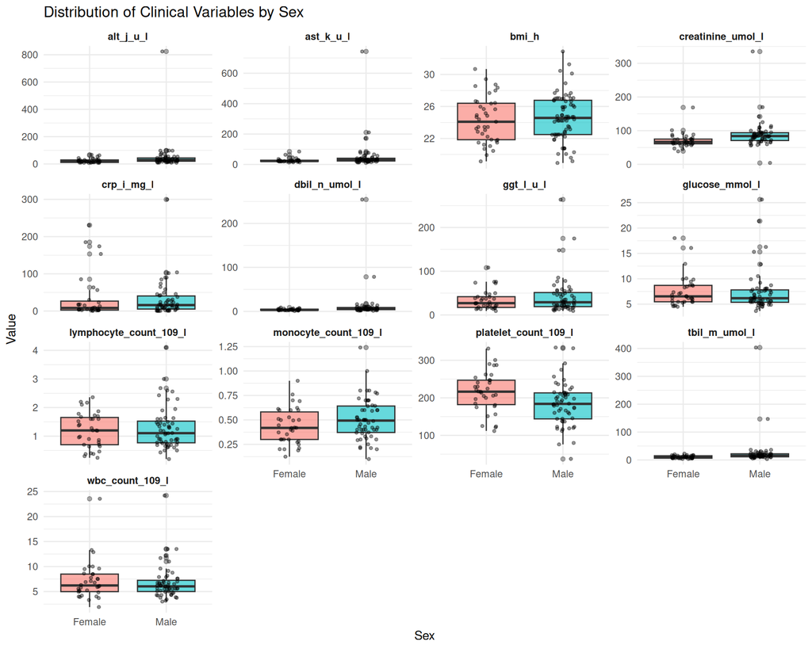

```r
ggplot(long_clinical, aes(x = sex_g, y = value, fill = sex_g)) +
  geom_boxplot(outlier.alpha = 0.4, alpha = 0.6) +
  geom_jitter(width = 0.15, alpha = 0.4, size = 1) +
  facet_wrap(~ variable, scales = "free_y") +
  labs(
    title = "Distribution of Clinical Variables by Sex",
    x = "Sex", y = "Value"
  ) +
  theme_minimal() +
  theme(legend.position = "none", strip.text = element_text(face = "bold"))
```

```r
sex_comparison <- long_clinical %>%
  group_by(variable) %>%
  wilcox_test(value ~ sex_g) %>%
  adjust_pvalue(method = "BH") %>%
  select(variable, n1, n2, p, p.adj)

sex_comparison
```

```
## # A tibble: 13 × 5
##    variable                  n1    n2         p    p.adj
##    <chr>                  <int> <int>     <dbl>    <dbl>
##  1 alt_j_u_l                 34    56 0.00726   0.0189
##  2 ast_k_u_l                 34    56 0.0152    0.0329
##  3 bmi_h                     39    71 0.538     0.698
##  4 creatinine_umol_l         34    56 0.000105  0.000680
##  5 crp_i_mg_l                31    54 0.491     0.698
##  6 dbil_n_umol_l             34    56 0.000157  0.000680
##  7 ggt_l_u_l                 34    56 0.644     0.698
##  8 glucose_mmol_l            34    56 0.378     0.614
##  9 lymphocyte_count_109_l    34    56 0.924     0.924
## 10 monocyte_count_109_l      34    56 0.105     0.195
## 11 platelet_count_109_l      34    56 0.00618   0.0189
## 12 tbil_m_umol_l             34    56 0.0000647 0.000680
## 13 wbc_count_109_l           34    56 0.591     0.698
```

Most clinical variables show substantial overlap between sexes. Significant differences were observed for ALT, AST, creatinine, and bilirubin, consistent with known physiological sex differences. Overall, sex is unlikely to act as a major confounder in severity-based analyses.

### EDA Summary

Data cleaning ensured consistent variable formats, correct date handling, and appropriate factor definitions. Variables with high missingness were structurally driven (not applicable to healthy or non-severe patients) rather than data quality issues.

Most clinical variables showed strong right-skewness, confirmed by histograms, Q-Q plots, and Shapiro-Wilk tests. Non-parametric methods were therefore used for group comparisons.

Comparative analyses revealed significant differences across disease groups for CRP, glucose, lymphocyte count, AST, and WBC count, with the strongest contrasts between non-severe and severe COVID-19 patients. Sex-based analyses showed limited effects overall, with significant differences only in a subset of laboratory parameters consistent with known physiological sex differences.

# Exercise 2

## Exercise 2.1

**Reproduce Supplementary Figure 1 using the data without modifying or removing any observations. Use the same variables and groupings as in the original figure.**

The original Figure S1 shows boxplots with jittered points for 12 clinical variables across three groups (non-COVID-19, non-Severe, Severe), with significance brackets from unpaired Welch’s t-tests.

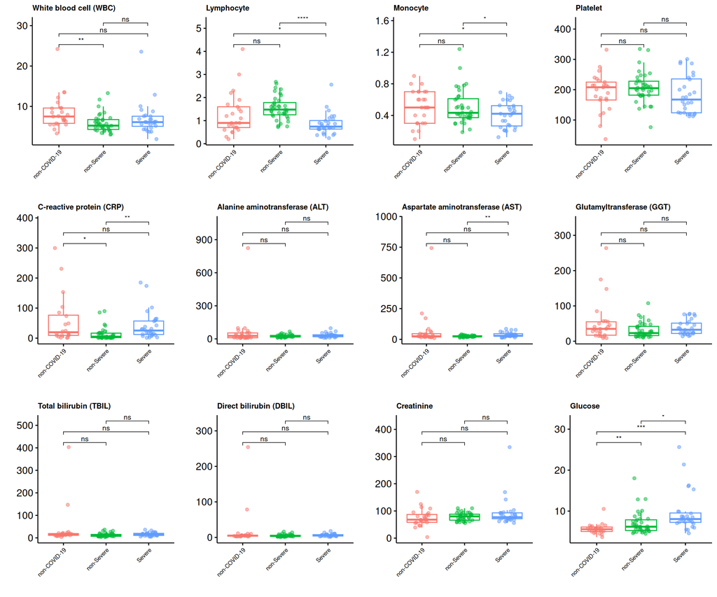

```r
# Filter to the three groups in Figure S1
df_s1 <- data_eda %>%
  filter(group_d %in% c("non-COVID-19", "non-Severe", "Severe")) %>%
  droplevels()

# Pivot to long format with readable labels
df_long_s1 <- df_s1 %>%
  pivot_longer(
    cols = all_of(names(clinical_labels)),
    names_to = "variable",
    values_to = "value"
  ) %>%
  filter(!is.na(value)) %>%
  mutate(variable = factor(variable,
                           levels = names(clinical_labels),
                           labels = clinical_labels))

# Define pairwise comparisons matching the original figure
my_comparisons <- list(
  c("non-COVID-19", "non-Severe"),
  c("non-COVID-19", "Severe"),
  c("non-Severe", "Severe")
)

# Create individual plots
plot_list <- lapply(levels(df_long_s1$variable), function(var) {
  d <- filter(df_long_s1, variable == var)
  ggboxplot(d, x = "group_d", y = "value",
            color = "group_d", add = "jitter",
            add.params = list(size = 1.5, alpha = 0.5)) +
    stat_compare_means(comparisons = my_comparisons,
                       method = "t.test",
                       label = "p.signif",
                       size = 3) +
    labs(title = var, x = "", y = "") +
    theme(legend.position = "none",
          axis.text.x = element_text(angle = 45, hjust = 1, size = 7),
          plot.title = element_text(size = 9, face = "bold"))
})

# Arrange in a 4x3 grid (matching the original figure layout)
ggarrange(plotlist = plot_list, ncol = 4, nrow = 3)
```

The reproduced figure shows the same patterns as the original: significant lymphopenia and suppressed monocyte counts in severe patients, elevated CRP and AST, and increased glucose levels. The significance brackets match the asterisk annotations in the published Figure S1.

## Exercise 2.2

**Identify and handle outliers using an appropriate and well-justified method (e.g. removal, transformation, or robust statistics).**

**Reproduce Supplementary Figure 1 after outlier handling and discuss how and why the results change.**

We use **winsorization** (capping extreme values at 1.5×IQR boundaries) rather than removal, because clinical outliers in biomedical data often represent real pathological states rather than measurement errors. Removing them could bias results toward milder presentations.

```r
# Count outliers per variable using the IQR criterion

outlier_counts <- df_s1 %>%
  pivot_longer(cols = all_of(names(clinical_labels)),
               names_to = "variable", values_to = "value") %>%
  filter(!is.na(value)) %>%
  group_by(variable) %>%
  summarise(
    n = n(),
    n_outliers = {
      q <- quantile(value, c(0.25, 0.75))
      iqr_val <- q[2] - q[1]
      sum(value < q[1] - 1.5 * iqr_val | value > q[2] + 1.5 * iqr_val)
    },
    pct_outliers = round(n_outliers / n * 100, 1),
    .groups = "drop"
  )

outlier_counts
```

```
## # A tibble: 12 × 4
##    variable                   n n_outliers pct_outliers
##    <chr>                  <int>      <int>        <dbl>
##  1 alt_j_u_l                 90          7          7.8
##  2 ast_k_u_l                 90         12         13.3
##  3 creatinine_umol_l         90          6          6.7
##  4 crp_i_mg_l                85          9         10.6
##  5 dbil_n_umol_l             90          6          6.7
##  6 ggt_l_u_l                 90          4          4.4
##  7 glucose_mmol_l            90          8          8.9
##  8 lymphocyte_count_109_l    90          2          2.2
##  9 monocyte_count_109_l      90          1          1.1
## 10 platelet_count_109_l      90          1          1.1
## 11 tbil_m_umol_l             90          5          5.6
## 12 wbc_count_109_l           90          7          7.8
```

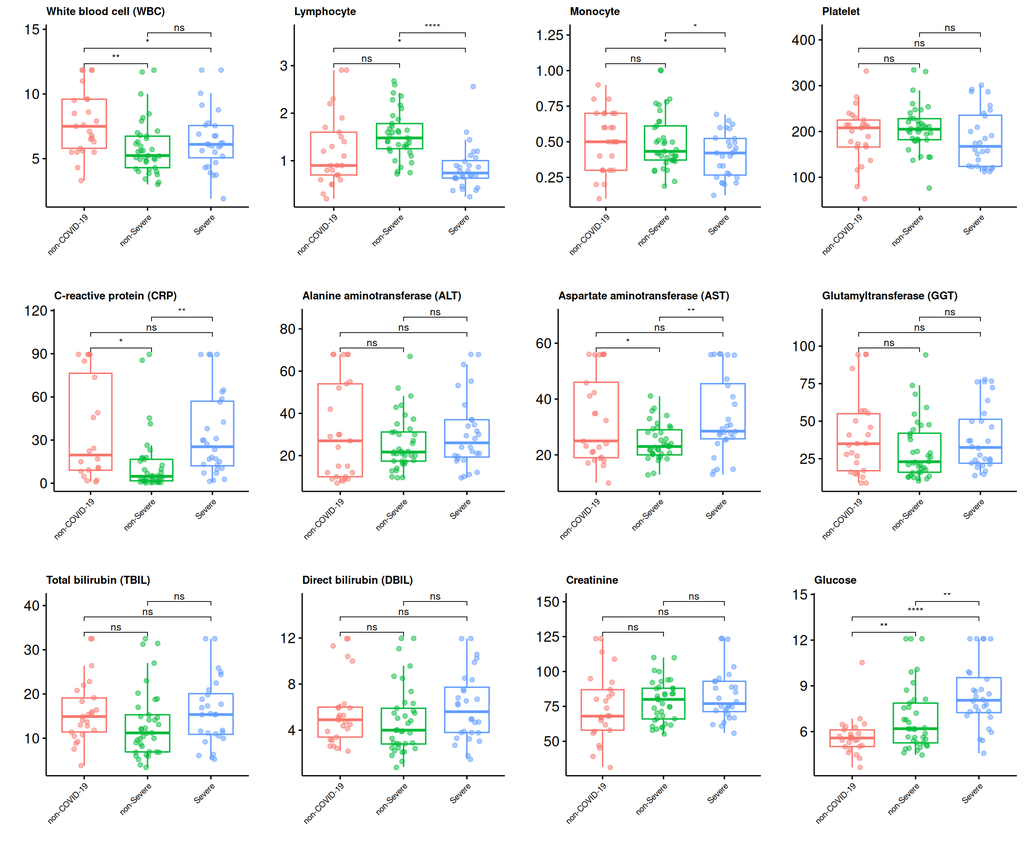

```r
# Winsorize function: cap values at Q1 - 1.5*IQR and Q3 + 1.5*IQR
winsorize_iqr <- function(x) {
  q <- quantile(x, probs = c(0.25, 0.75), na.rm = TRUE)
  iqr_val <- q[2] - q[1]
  lower <- q[1] - 1.5 * iqr_val
  upper <- q[2] + 1.5 * iqr_val
  x[x < lower & !is.na(x)] <- lower
  x[x > upper & !is.na(x)] <- upper
  x
}

# Apply winsorization
df_s1_win <- df_s1 %>%
  mutate(across(all_of(names(clinical_labels)), winsorize_iqr))

# Pivot winsorized data to long format
df_long_win <- df_s1_win %>%
  pivot_longer(
    cols = all_of(names(clinical_labels)),
    names_to = "variable",
    values_to = "value"
  ) %>%
  filter(!is.na(value)) %>%
  mutate(variable = factor(variable,
                           levels = names(clinical_labels),
                           labels = clinical_labels))

# Reproduce Figure S1 after winsorization
plot_list_win <- lapply(levels(df_long_win$variable), function(var) {
  d <- filter(df_long_win, variable == var)
  ggboxplot(d, x = "group_d", y = "value",
            color = "group_d", add = "jitter",
            add.params = list(size = 1.5, alpha = 0.5)) +
    stat_compare_means(comparisons = my_comparisons,
                       method = "t.test",
                       label = "p.signif",
                       size = 3) +
    labs(title = var, x = "", y = "") +
    theme(legend.position = "none",
          axis.text.x = element_text(angle = 45, hjust = 1, size = 7),
          plot.title = element_text(size = 9, face = "bold"))
})

ggarrange(plotlist = plot_list_win, ncol = 4, nrow = 3)
```

### Discussion: Effect of outlier handling

# Exercise 3

Create a heatmap of the biomarker data. Include group and gender as annotation variables.

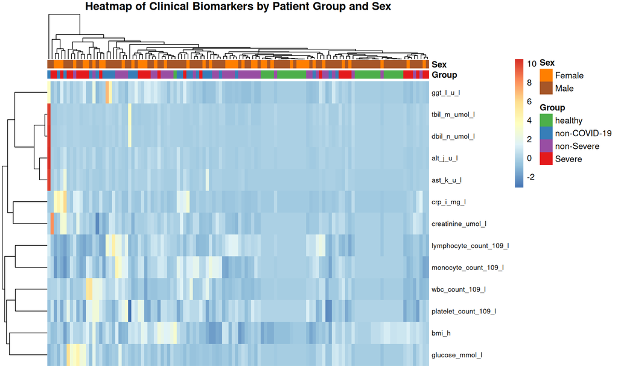

```r
# Prepare the matrix: samples as rows, variables as columns
mat <- data_eda %>%
  select(all_of(clinical_variables)) %>%
  mutate(across(everything(), as.numeric)) %>%
  as.matrix()

# Remove variables with >40% missing
missing_prop <- colMeans(is.na(mat))
mat <- mat[, missing_prop < 0.40]

# Impute remaining NAs with column medians
for (j in seq_len(ncol(mat))) {
  med <- median(mat[, j], na.rm = TRUE)
  mat[is.na(mat[, j]), j] <- med
}

# Z-score scale
mat_scaled <- scale(mat)

# pheatmap expects variables as rows, samples as columns
mat_t <- t(mat_scaled)

# Annotation for columns (each column = one sample)
annot <- data.frame(
  Group = data_eda$group_d,
  Sex   = data_eda$sex_g,
  row.names = paste0("S", seq_len(nrow(data_eda)))
)
colnames(mat_t) <- rownames(annot)

ann_colors <- list(
  Group = c(
    "healthy"      = "#4DAF4A",
    "non-COVID-19" = "#377EB8",
    "non-Severe"   = "#984EA3",
    "Severe"       = "#E41A1C"
  ),
  Sex = c(
    "Female" = "#FF7F00",
    "Male"   = "#A65628"
  )
)

pheatmap(
  mat_t,
  annotation_col = annot,
  annotation_colors = ann_colors,
  clustering_method = "complete",
  clustering_distance_cols = "euclidean",
  clustering_distance_rows = "euclidean",
  show_colnames = FALSE,
  fontsize_row = 8,
  main = "Heatmap of Clinical Biomarkers by Patient Group and Sex"
)
```

# Conclusion

# Session Info

R version 4.5.3 (2026-03-11) Platform: x86_64-pc-linux-gnu Running under: Ubuntu 24.04.4 LTS

Matrix products: default BLAS: /usr/lib/x86_64-linux-gnu/openblas-pthread/libblas.so.3 LAPACK: /usr/lib/x86_64-linux-gnu/openblas-pthread/libopenblasp-r0.3.26.so; LAPACK version 3.12.0

locale: [1] LC_CTYPE=en_US.UTF-8 LC_NUMERIC=C  
[3] LC_TIME=en_US.UTF-8 LC_COLLATE=en_US.UTF-8  
[5] LC_MONETARY=en_US.UTF-8 LC_MESSAGES=en_US.UTF-8  
[7] LC_PAPER=en_US.UTF-8 LC_NAME=C  
[9] LC_ADDRESS=C LC_TELEPHONE=C  
[11] LC_MEASUREMENT=en_US.UTF-8 LC_IDENTIFICATION=C

time zone: Europe/Madrid tzcode source: system (glibc)

attached base packages: [1] stats graphics grDevices utils datasets methods base

other attached packages: [1] rvest_1.0.5 xml2_1.5.2 htmltools_0.5.9 table1_1.5.1  
[5] pheatmap_1.0.13 ggpubr_0.6.3 rstatix_0.7.3 naniar_1.1.0  
[9] janitor_2.2.1 readxl_1.4.5 lubridate_1.9.5 forcats_1.0.1  
[13] stringr_1.6.0 dplyr_1.2.0 purrr_1.2.1 readr_2.2.0  
[17] tidyr_1.3.2 tibble_3.3.1 ggplot2_4.0.2 tidyverse_2.0.0

loaded via a namespace (and not attached): [1] gtable_0.3.6 xfun_0.57 bslib_0.10.0 visdat_0.6.0  
[5] tzdb_0.5.0 vctrs_0.7.2 tools_4.5.3 generics_0.1.4  
[9] pkgconfig_2.0.3 RColorBrewer_1.1-3 S7_0.2.1 lifecycle_1.0.5  
[13] compiler_4.5.3 farver_2.1.2 carData_3.0-6 snakecase_0.11.1  
[17] sass_0.4.10 yaml_2.3.12 Formula_1.2-5 pillar_1.11.1  
[21] car_3.1-5 jquerylib_0.1.4 cachem_1.1.0 abind_1.4-8  
[25] tidyselect_1.2.1 digest_0.6.39 stringi_1.8.7 labeling_0.4.3  
[29] cowplot_1.2.0 fastmap_1.2.0 grid_4.5.3 cli_3.6.5  
[33] magrittr_2.0.4 utf8_1.2.6 broom_1.0.12 withr_3.0.2  
[37] scales_1.4.0 backports_1.5.0 timechange_0.4.0 rmarkdown_2.30  
[41] httr_1.4.8 ggsignif_0.6.4 cellranger_1.1.0 hms_1.1.4  
[45] evaluate_1.0.5 knitr_1.51 viridisLite_0.4.3 rlang_1.1.7  
[49] glue_1.8.0 rstudioapi_0.18.0 jsonlite_2.0.0 R6_2.6.1